# Logistic Regression

#### Classification

We already learned how to compare models using the deviance, but how do we know how well our model works? One techinque for assessing the goodness-of-fit in a logistic regression model is to examine the percentage of the time that our model was “right.”

Return to the logistic model that we built for $isAlive$ as a function of $age$ and $smoker$.

```r
logm <- glm(isAlive ~ age + smoker, data=Whickham, family=binomial)
summary(logm)
```

```
##
## Call:
## glm(formula = isAlive ~ age + smoker, family = binomial, data = Whickham)
##
## Deviance Residuals:
##     Min       1Q   Median       3Q      Max
## -3.2795  -0.4381   0.2228   0.5458   1.9581
##
## Coefficients:
##              Estimate Std. Error z value Pr(>|z|)
## (Intercept)  7.599221   0.441231  17.223   <2e-16 ***
## age         -0.123683   0.007177 -17.233   <2e-16 ***
## smokerYes   -0.204699   0.168422  -1.215    0.224
## ---
## Signif. codes:  0 '***' 0.001 '**' 0.01 '*' 0.05 '.' 0.1 ' ' 1
##
## (Dispersion parameter for binomial family taken to be 1)
##
##     Null deviance: 1560.32  on 1313  degrees of freedom
## Residual deviance:  945.02  on 1311  degrees of freedom
## AIC: 951.02
##
## Number of Fisher Scoring iterations: 6
```

When we visualize the model, it’s hard to assess how often our model is correct. (This isn’t *exactly* our model, but it’s close)

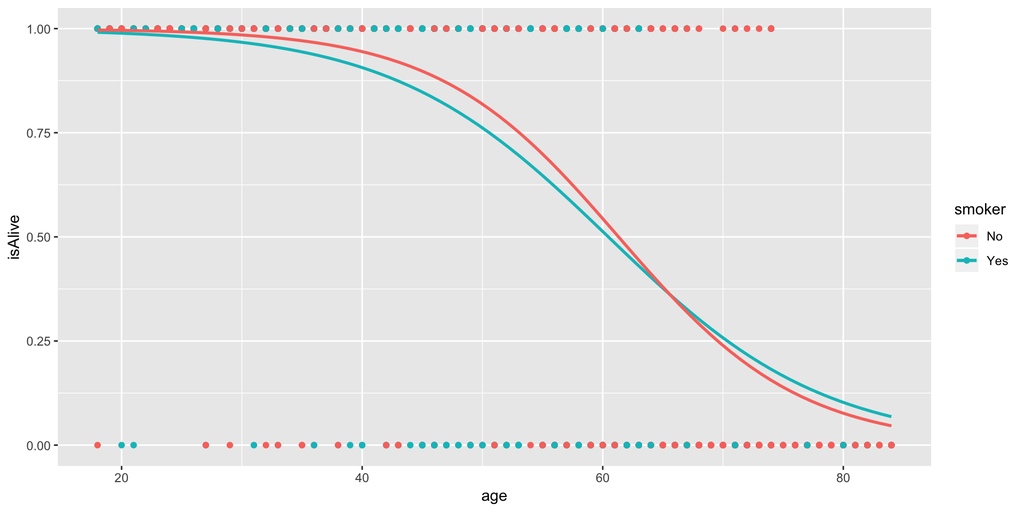

```r
ggplot(Whickham, aes(y=isAlive, x=age, col=smoker)) +  geom_point() +
  geom_smooth(data=filter(Whickham, smoker=="Yes"), method = "glm", formula='y~x', method.args = list(family = "binomial"), se = FALSE) +
  geom_smooth(data=filter(Whickham, smoker=="No"), method = "glm", formula='y~x', method.args = list(family = "binomial"), se = FALSE)
```

Moreover, what does it even mean to be correct? The response variable is binary, but the predictions generated by the model are quantities on $[0,1]$. A simple way to **classify** the fitted values of our model is to simply round them off. Once we do this, we can tabulate how often the rounded-off probability from the model agrees with the actual response variable.

```r
Whickham <- Whickham %>%
  mutate(fitted = fitted.values(logm)) %>%
  mutate(fitalive = ifelse(fitted >= 0.5, 1, 0))
tbl <- table(Whickham$isAlive, Whickham$fitalive)
tbl
```

```
##
##       0   1
##   0 251 118
##   1  94 851
```

```r
sum(diag(tbl)) / nrow(Whickham)
```

```
## [1] 0.8386606
```

Thus, our model was correct nearly 84% of the time. Is that good? It depends on the application…

We might want to compare this with what would happen if we used the null model, just predicting every value by the mean

```r
Whickham %>%
  skim(isAlive)
```

```
## Skim summary statistics
##  n obs: 1314
##  n variables: 8
##
## ── Variable type:numeric ───────────────────────────────────────────────────────────────────────────────────────────────────
##  variable missing complete    n mean   sd p0 p25 p50 p75 p100     hist
##   isAlive       0     1314 1314 0.72 0.45  0   0   1   1    1 ▃▁▁▁▁▁▁▇
```

or if we had just flipped a coin instead of using a model at all.

```r
Whickham <- Whickham %>%
   mutate(fitalive = sample(c(0,1), size=1314, replace=TRUE))
table(Whickham$isAlive, Whickham$fitalive)
```

```
##
##       0   1
##   0 193 176
##   1 472 473
```

1. Which of these “models” is best?

#### Concordance

A more sophisticated technique for assessing the quality of fit is to examine the $C$-statistic, where $C$ stands for **concordance**. The idea here is to pair up each actual success with each actual failure, and then compute whether the fitted probability for the success was greater than the fitted probability for the failure. The percentage of pairs statisfying this condition makes up the $C$-statistic.

Note that even if our model had no predictive power, it would still be right about half of the time. Thus, the $C$-statistic for two randomly generated vectors is about 0.5.

```r
X <- data.frame(a = runif(10000), b = runif(10000))
# install.packages("Hmisc")
library(Hmisc)
rcorrcens(a~b, data=X)
```

```
##
## Somers' Rank Correlation for Censored Data    Response variable:a
##
##     C Dxy aDxy    SD    Z      P     n
## b 0.5   0    0 0.007 0.04 0.9676 10000
```

In this case our model is much more effective.

```r
rcorrcens(isAlive ~ fitted.values(logm), data=Whickham)
```

```
##
## Somers' Rank Correlation for Censored Data    Response variable:isAlive
##
##                         C   Dxy  aDxy   SD    Z P    n
## fitted.values(logm) 0.893 0.786 0.786 0.02 39.6 0 1314
```

```r
# warning! Hmisc may mess with dplyr. After you're done with it, it's good to
detach(package:Hmisc)
```